# EDS 223: assignment 4

Flora Hamilton

2022-12-8

## Overview

Marine aquaculture has the potential to play an important role in the global food supply as a more sustainable protein option than land-based meat production.[^1] [Gentry et al.](https://www.nature.com/articles/s41559-017-0257-9) mapped the potential for marine aquaculture globally based on multiple constraints, including ship traffic, dissolved oxygen, bottom depth .[^2]

For this assignment, you are tasked with determining **which Exclusive Economic Zones (EEZ) on the West Coast** of the US are best suited to developing marine aquaculture for several species of oysters.

Based on previous research, we know that oysters needs the following conditions for optimal growth:

- **sea surface temperature: 11-30°C**
- **depth: 0-70 meters below sea level**

##### Learning objectives:

- combining vector/raster data
- resampling raster data
- masking raster data
- map algebra

### Data

#### Sea Surface Temperature

We will use average annual sea surface temperature (SST) from the years 2008 to 2012 to characterize the average sea surface temperature within the region. The data we are working with was originally generated from [NOAA’s 5km Daily Global Satellite Sea Surface Temperature Anomaly v3.1](https://coralreefwatch.noaa.gov/product/5km/index_5km_ssta.php).

#### Bathymetry

To characterize the depth of the ocean we will use the [General Bathymetric Chart of the Oceans (GEBCO)](https://www.gebco.net/data_and_products/gridded_bathymetry_data/#area).[^3]

#### Exclusive Economic Zones

We will be designating maritime boundaries using Exclusive Economic Zones off of the west coast of US from [Marineregions.org](https://www.marineregions.org/eez.php).

## Assignment

Below is an outline of the steps you should consider taking to achieve the assignment tasks.

#### Prepare data (5 points)

To start, we need to load all necessary data and make sure it has the coordinate reference system.

- load necessary packages and set path
  - I recommend using the [`here` package](https://here.r-lib.org/)

```r
#Loading libraries

library(sf)
library(terra)
library(here)
library(dplyr)
library(rpart)
library(rpart.plot)
library(tmap)
library(maptiles)

#setting filepath
here::i_am("assignment4.Rmd")
setwd(here::here())
```

- read in the shapefile for the West Coast EEZ (`wc_regions_clean.shp`)

```r
#reading in wc_regions eez shapefile

wc_regions <- st_read("~/dev/eds223/assignment-4-floraham/data/wc_regions_clean.shp")
```

- read in SST rasters
  - `average_annual_sst_2008.tif`
  - `average_annual_sst_2009.tif`
  - `average_annual_sst_2010.tif`
  - `average_annual_sst_2011.tif`
  - `average_annual_sst_2012.tif`

```r
#reading in all the tif files at once
files <- list.files(here("data"), pattern = "average*", full.names = TRUE)
```

- combine SST rasters into a raster stack

```r
#using a function to create a stack

 create_sst_layer <- function(i){
   sst <- rast(files[i])
 }

# create SST layer for each scene (day) and stack into a single rasterstack
all_sst <- c(create_sst_layer(1),
              create_sst_layer(2),
              create_sst_layer(3),
              create_sst_layer(4),
              create_sst_layer(5)
              )

 #update layer names to match date
 names(all_sst) <- c("avg_2008", "avg_2009", "avg_2010", "avg_2011", "2012")


 #check that there's a stack (5 layers)
 all_sst
```

```
## class       : SpatRaster
## dimensions  : 480, 408, 5  (nrow, ncol, nlyr)
## resolution  : 0.04166185, 0.04165702  (x, y)
## extent      : -131.9848, -114.9867, 29.99305, 49.98842  (xmin, xmax, ymin, ymax)
## coord. ref. : lon/lat WGS 84
## sources     : average_annual_sst_2008.tif
##               average_annual_sst_2009.tif
##               average_annual_sst_2010.tif
##               ... and 2 more source(s)
## names       : avg_2008, avg_2009, avg_2010, avg_2011,   2012
## min values  :  278.700,   278.08,   279.92, 278.8600, 278.13
## max values  :  301.445,   301.50,   300.96, 307.2733, 310.20
```

- read in bathymetry raster (`depth.tif`)

```r
#reading depth / bathymetry dataset
depth <- rast(here("data", "depth.tif"))
```

- check that data are in the same coordinate reference system
  - reproject any data not in the same projection

```r
##check crs's of all of our relevant datasets
st_crs(depth)
```

```
## Coordinate Reference System:
##   User input: WGS 84
##   wkt:
## GEOGCRS["WGS 84",
##     ENSEMBLE["World Geodetic System 1984 ensemble",
##         MEMBER["World Geodetic System 1984 (Transit)"],
##         MEMBER["World Geodetic System 1984 (G730)"],
##         MEMBER["World Geodetic System 1984 (G873)"],
##         MEMBER["World Geodetic System 1984 (G1150)"],
##         MEMBER["World Geodetic System 1984 (G1674)"],
##         MEMBER["World Geodetic System 1984 (G1762)"],
##         MEMBER["World Geodetic System 1984 (G2139)"],
##         ELLIPSOID["WGS 84",6378137,298.257223563,
##             LENGTHUNIT["metre",1]],
##         ENSEMBLEACCURACY[2.0]],
##     PRIMEM["Greenwich",0,
##         ANGLEUNIT["degree",0.0174532925199433]],
##     CS[ellipsoidal,2],
##         AXIS["geodetic latitude (Lat)",north,
##             ORDER[1],
##             ANGLEUNIT["degree",0.0174532925199433]],
##         AXIS["geodetic longitude (Lon)",east,
##             ORDER[2],
##             ANGLEUNIT["degree",0.0174532925199433]],
##     USAGE[
##         SCOPE["Horizontal component of 3D system."],
##         AREA["World."],
##         BBOX[-90,-180,90,180]],
##     ID["EPSG",4326]]
```

```r
st_crs(all_sst) #the only one that is not in EPSG 4326
```

```
## Coordinate Reference System:
##   User input: WGS 84
##   wkt:
## GEOGCRS["WGS 84",
##     DATUM["unknown",
##         ELLIPSOID["WGS84",6378137,298.257223563,
##             LENGTHUNIT["metre",1,
##                 ID["EPSG",9001]]]],
##     PRIMEM["Greenwich",0,
##         ANGLEUNIT["degree",0.0174532925199433,
##             ID["EPSG",9122]]],
##     CS[ellipsoidal,2],
##         AXIS["latitude",north,
##             ORDER[1],
##             ANGLEUNIT["degree",0.0174532925199433,
##                 ID["EPSG",9122]]],
##         AXIS["longitude",east,
##             ORDER[2],
##             ANGLEUNIT["degree",0.0174532925199433,
##                 ID["EPSG",9122]]]]
```

```r
st_crs(wc_regions)
```

```
## Coordinate Reference System:
##   User input: WGS 84
##   wkt:
## GEOGCRS["WGS 84",
##     DATUM["World Geodetic System 1984",
##         ELLIPSOID["WGS 84",6378137,298.257223563,
##             LENGTHUNIT["metre",1]]],
##     PRIMEM["Greenwich",0,
##         ANGLEUNIT["degree",0.0174532925199433]],
##     CS[ellipsoidal,2],
##         AXIS["latitude",north,
##             ORDER[1],
##             ANGLEUNIT["degree",0.0174532925199433]],
##         AXIS["longitude",east,
##             ORDER[2],
##             ANGLEUNIT["degree",0.0174532925199433]],
##     ID["EPSG",4326]]
```

```r
#reproject all_sst using terra::project
all_sst <- project(all_sst, "EPSG:4326")

##check whether they have the same crs now:
print(paste("second check: ", crs(depth) == crs(all_sst)))
```

```
## [1] "second check:  TRUE"
```

#### Process data (10 points)

Next, we need process the SST and depth data so that they can be combined. In this case the SST and depth data have slightly different resolutions, extents, and positions. We don’t want to change the underlying depth data, so we will need to re-sample to match the SST data using the nearest neighbor approach.

- find the mean SST from 2008-2012
- convert SST data from Kelvin to Celsius
  - hint: subtract by 273.15

  ```r
  # use app() from terra to apply the mean function to all_sst
  mean_sst <- terra::app(all_sst, mean)

  # now convert to celcis
  mean_sst_celcius <- mean_sst - 273.15
  ```

- crop depth raster to match the extent of the SST raster
- note: the resolutions of the SST and depth data do not match
  - resample the depth data to match the resolution of the SST data using the nearest neighbor approach
  - check that the depth and SST match in resolution, extent, and coordinate reference system
    - hint: can the rasters be stacked

  ```r
  #now we crop depth to match SST raster extent using crop() function
  depth_cropped <- crop(depth, mean_sst_celcius)

  # Re-sample the depth data to match with SST resolution, using nearest neighbors approach
  depth_resampled <- terra::resample(depth_cropped, mean_sst_celcius, method = "near")

  # Stack rasters, check that depth and SST match in resolution, extent, and crs
  depth_sst_stacked <- c(mean_sst_celcius, depth_resampled)

  #checking whether they stack. Yes, they stack!
  depth_sst_stacked
  ```

  ```
  ## class       : SpatRaster
  ## dimensions  : 480, 408, 2  (nrow, ncol, nlyr)
  ## resolution  : 0.04165905, 0.04165905  (x, y)
  ## extent      : -131.9848, -114.9879, 29.99208, 49.98842  (xmin, xmax, ymin, ymax)
  ## coord. ref. : lon/lat WGS 84 (EPSG:4326)
  ## source(s)   : memory
  ## names       :      mean, depth
  ## min values  :  8.217548, -5468
  ## max values  : 28.033722,  4218
  ```

### **Find suitable locations (20)**

In order to find suitable locations for marine aquaculture, we’ll need to find locations that are suitable in terms of both SST and depth.

- reclassify SST and depth data into locations that are suitable for oysters
  - hint: set suitable values to `1` and unsuitable values to `NA`

  ```r
  ## create reclassification matrix using oyster temeperatures. Remind ourselves that oysters need these conditions to survive:
  #1) sea surface temperature: 11-30°C
  #2) a depth of: 0-70 meters below sea level

  ## first we create the reclassification matrix for suitable temperature conditions. there's only 1 group we're looking for.

  #reclassify oyster temp
  temp_vec <- c(-Inf, 11, NA,
                   11, 30, 1,
                   30, Inf, NA)
  #set up matrix
  temp_matrix <- matrix(temp_vec, ncol = 3, byrow = TRUE)

  #reclassify sst using matrix
  temp_reclass <- classify(mean_sst_celcius, temp_matrix)


  #reclassify depth using same approach
  depth_vec <- c(-Inf, -70, NA,
                 -70, 0, 1,
                 0, Inf, NA)
  depth_matrix <- matrix(depth_vec, ncol = 3, byrow = TRUE)
  depth_reclass <- classify(depth_resampled, depth_matrix, include.lowest = TRUE)


  ##now we need to stack & combine the reclassified matrices so we can multiply cell values in the next step

  # stack the two matrices
  matrices <- c(depth_reclass, temp_reclass)

  #Combine both matrices and stacked raster
  matrix_sst <- c(matrices, depth_sst_stacked)
  ```

- find locations that satisfy **both SST and depth conditions**
  - hint: create an overlay using the `lapp()` function multiplying cell values

```r
#create function with two inputs that multiples the cell values
condition_satisfy <- function(x,y){
  return(x * y)
}

#apply the function
suitable_locations <- lapp(matrices[[c(1,2)]], fun = condition_satisfy)

print(suitable_locations)
```

```
## class       : SpatRaster
## dimensions  : 480, 408, 1  (nrow, ncol, nlyr)
## resolution  : 0.04165905, 0.04165905  (x, y)
## extent      : -131.9848, -114.9879, 29.99208, 49.98842  (xmin, xmax, ymin, ymax)
## coord. ref. : lon/lat WGS 84 (EPSG:4326)
## source(s)   : memory
## name        : lyr1
## min value   :    1
## max value   :    1
```

#### Determine the most suitable EEZ (20 points)

We want to determine the total suitable area within each EEZ in order to rank zones by priority. To do so, we need to **find the total area of suitable locations within each EEZ.**

- select suitable cells within West Coast EEZs
- find area of grid cells
- find the percentage of each zone that is suitable
  - hint it might be helpful to join the suitable area by region onto the EEZ vector data

```r
#select suitable cells within West Coast EEZs

## we can use Terra's cellSize() function to find area of grid cells. The dataset's documentation suggests that it is measured in km.

suitable_cells_eez <- cellSize(suitable_locations, unit = 'km', transform = TRUE)


#find the total suitable area within each EEZ. We can rasterize the EEZ data first to find the matching overlap. We would use the "rgn" field

eez_rasterized <- rasterize(wc_regions, suitable_locations, field= 'rgn')

#check eez_rasterized to se what it looks like.
#plot(eez_rasterized)

mask_eez <-  mask(eez_rasterized, suitable_locations)

#we use zonal() to calculate the area. The RDocumentation describes zonal() as: "zonal() function calculates zonal statistics. Zonal statistics summarize the values of a Raster* object for each zone defined by a RasterLayer"
area_zone_km2 <- zonal(suitable_cells_eez, mask_eez, fun = 'sum')
```

```r
#finding the percentage of each zone that is suitable by joining the suitable area by region onto the EEZ vector data

#left join west coast eez regions & area by region column, and an additional column for the percentage.
eez_summary <-  left_join(wc_regions, area_zone_km2, by = 'rgn') |>
  mutate(area_suitable_km2 = area,
         percentage_zone = (area_suitable_km2 / area_km2) * 100,
         .before = geometry)


region_perc_suitable <- data.frame(region = eez_summary$rgn, percent_suitable = eez_summary$percentage_zone)
```

#### Visualize results (5 points)

Now that we have results, we need to present them!

Create the following maps:

- total suitable area by region
- percent suitable area by region

  Include:
  - legible legends
  - updated color aesthetics
  - basemap

```r
## map total suitable area by region

tmap_mode("plot")
```

```
## tmap mode set to 'plot'
```

```r
tm_shape(eez_summary) +
    tm_polygons(fill = "area",
    title = "Area (km2)", alpha = 0.7, palette = "Viridis") +
    tm_shape(wc_regions) + tm_polygons(alpha=0) + tm_text("rgn_key", size = 0.7) +
     tm_scalebar(position = c("RIGHT", "BOTTOM")) +
                tm_graticules(alpha = 0.4) +
                tm_basemap("CartoDB.Positron") +
  tm_layout(legend.outside = TRUE,
            main.title = paste("Total Area for Suitable Oyster Aquaculture by EEZ" ),
            frame = T)
```

```
## Deprecated tmap v3 code detected. Code translated to v4
```

```
## Deprecated tmap v3 code detected. Code translated to v4
```

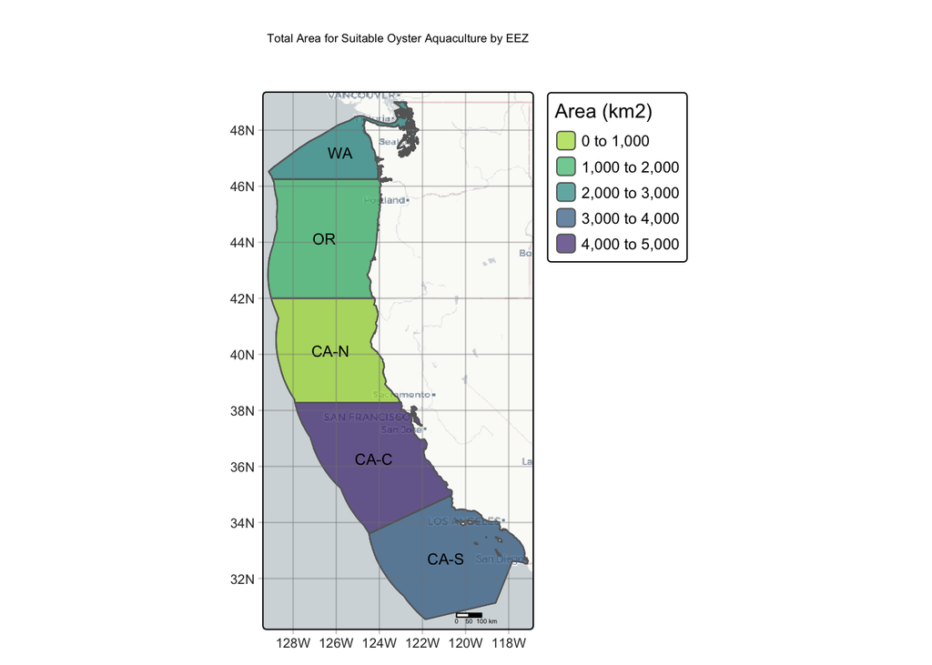

- percent suitable area by region

```r
## total suitable area by region

tmap_mode("plot")
```

```
## tmap mode set to 'plot'
```

```r
tm_shape(eez_summary) +
    tm_polygons(fill = "percentage_zone",
    title = "Percent (%)", alpha = 0.7, palette = "Viridis") +
    tm_shape(wc_regions) + tm_polygons(alpha=0) + tm_text("rgn_key", size = 0.7) +
     tm_scalebar(position = c("RIGHT", "BOTTOM")) +
                tm_graticules(alpha = 0.4) +
                tm_basemap("CartoDB.Positron") +
  tm_layout(legend.outside = TRUE,
            main.title = paste("Percentage Area for Suitable Oyster Aquaculture by EEZ" ),
            frame = T)
```

```
## Deprecated tmap v3 code detected. Code translated to v4
```

```
## Deprecated tmap v3 code detected. Code translated to v4
```

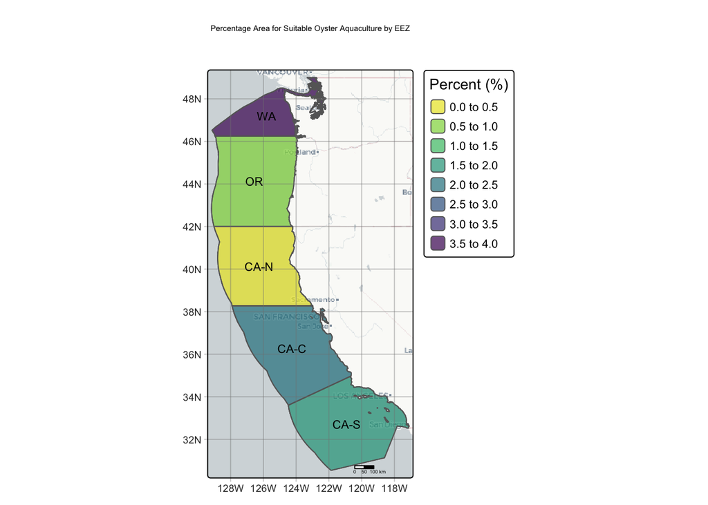

#### Broadening my workflow! (40 points)

Now that I’ve worked through the solution for one group of species, let’s update my workflow to work for other species. I’m creating a function that would allow me to reproduce my results for other species, which should be able to do the following:

- accept temperature and depth ranges and species name as inputs
- create maps of total suitable area and percent suitable area per EEZ with the species name in the title

```
## tmap mode set to 'plot'
```

```
## Deprecated tmap v3 code detected. Code translated to v4
## Deprecated tmap v3 code detected. Code translated to v4
## Deprecated tmap v3 code detected. Code translated to v4
## Deprecated tmap v3 code detected. Code translated to v4
```

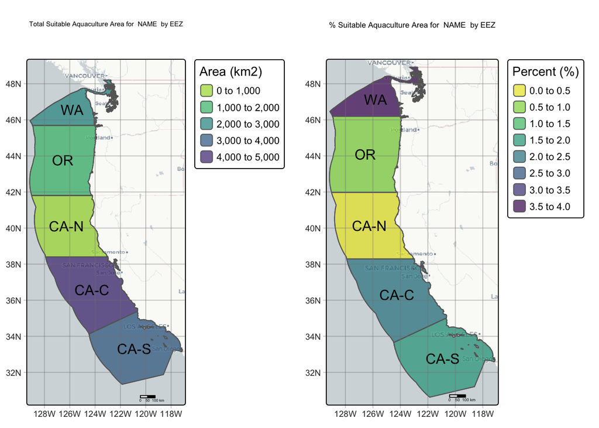

```r
## Default settings: Species = Oyster, min_temp: 11C, max_temp=30C, min_depth=0, max_depth=-70

suitable_location_any <- function(species = "NAME", min_temp = 11, max_temp = 30, min_depth = 0, max_depth = -70) {

#reclassify oyster temp (11-30)
temp_vec <- c(-Inf, min_temp, NA, min_temp, max_temp, 1, max_temp, Inf, NA)
temp_matrix <- matrix(temp_vec, ncol = 3, byrow = TRUE)
temp_reclass <- classify(mean_sst_celcius, temp_matrix)

#reclassify depth
depth_vec <- c(-Inf, max_depth, NA, max_depth, min_depth, 1, min_depth, Inf, NA)
depth_matrix <- matrix(depth_vec, ncol = 3, byrow = TRUE)
depth_reclass <- classify(depth_resampled, depth_matrix, include.lowest = TRUE)

# stack the two matrices
matrices <- c(depth_reclass, temp_reclass)

#Combine both matrices and stacked raster
matrix_sst <- c(matrices, depth_sst_stacked)

condition_satisfy <- function(x,y){return(x * y)}

suitable_locations <- lapp(matrices[[c(1,2)]], fun = condition_satisfy)

suitable_cells_eez <- cellSize(suitable_locations, unit = 'km', transform = TRUE)


#find the total suitable area within each EEZ. We can rasterize the EEZ data first to find the matching overlap. We would use the "rgn" field
eez_rasterized <- rasterize(wc_regions, suitable_locations, field= 'rgn')
mask_eez <-  mask(eez_rasterized, suitable_locations)

#calculate the area.
area_zone_km2 <- zonal(suitable_cells_eez, mask_eez, fun = 'sum')

eez_summary <-  left_join(wc_regions, area_zone_km2, by = 'rgn') |>
  mutate(area_suitable_km2 = area,
         percentage_zone = (area_suitable_km2 / area_km2) * 100,
         .before = geometry)

region_perc_suitable <- data.frame(region = eez_summary$rgn, percent_suitable = eez_summary$percentage_zone)



#--------------MAPPING--------------------#

tmap_mode("plot")

map <- tmap_arrange(
            tm_shape(eez_summary) +
                tm_polygons(fill = "area",
                title = "Area (km2)", alpha = 0.7, palette = "Viridis") +
                tm_shape(wc_regions) + tm_polygons(alpha=0) + tm_text("rgn_key") +
                tm_scalebar(position = c("RIGHT", "BOTTOM")) +
                tm_graticules(alpha = 0.4) +
                tm_layout(main.title = (paste("Total Suitable Aquaculture Area for ", species, " by EEZ" ))) +   tm_basemap("CartoDB.Positron"),
            tm_shape(eez_summary) +
                tm_polygons(fill = "percentage_zone",
                title = "Percent (%)", alpha = 0.7, palette = "Viridis") +
            tm_shape(wc_regions) + tm_polygons(alpha=0) + tm_text("rgn_key") +
                tm_scalebar(position = c("RIGHT", "BOTTOM")) +
                tm_graticules(alpha = 0.4) +
                tm_layout(legend.outside = TRUE,
                       #   basemaps = leaflet::providers$OpenStreetMap,
                          main.title = (paste("% Suitable Aquaculture Area for ", species, " by EEZ"))) +   tm_basemap("CartoDB.Positron")
            )
map
}


suitable_location_any()
```

Run your function for a species of your choice! You can find information on species depth and temperature requirements on [SeaLifeBase](https://www.sealifebase.ca/search.php). Remember, we are thinking about the potential for marine aquaculture, so these species should have some reasonable potential for commercial consumption.

```r
#---------RUNNING THE FUNCTION WITH YOUR CHOICE OF SPECIES-------------#

#Function Parameters: suitable_location_any(species = "___" , min_temp = ___, max_temp = ___, min_depth = ___, max_depth = -___)


# ## Default settings: Species = Oyster,
#                                min_temp: 11,
#                                max_temp=30,
#                                min_depth=0,
#                                max_depth=-70

# ## Example setting:  Species = California Mussel (Mytilus californianus)
#                                min_temp: 8.6,
#                                max_temp = 14.3,
#                                min_depth = 0,
#                                max_depth = -100
#

suitable_location_any(species = "California Mussel (Mytilus californianus", min_temp = 8.6, max_temp = 14.3, min_depth = 0, max_depth = -100)
```

```
## tmap mode set to 'plot'
```

```
## Deprecated tmap v3 code detected. Code translated to v4
## Deprecated tmap v3 code detected. Code translated to v4
## Deprecated tmap v3 code detected. Code translated to v4
## Deprecated tmap v3 code detected. Code translated to v4
```

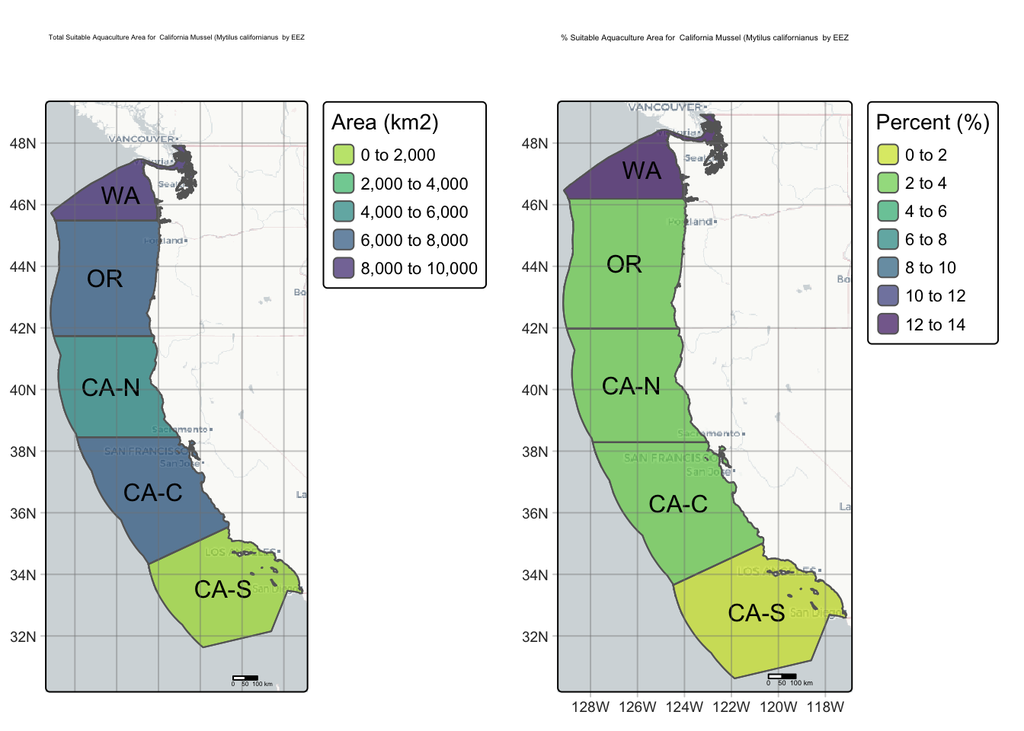

[^1]: Hall, S. J., Delaporte, A., Phillips, M. J., Beveridge, M. & O’Keefe, M. Blue Frontiers: Managing the Environmental Costs of Aquaculture (The WorldFish Center, Penang, Malaysia, 2011).
[^2]: Gentry, R. R., Froehlich, H. E., Grimm, D., Kareiva, P., Parke, M., Rust, M., Gaines, S. D., & Halpern, B. S. Mapping the global potential for marine aquaculture. *Nature Ecology & Evolution*, 1, 1317-1324 (2017).
[^3]: GEBCO Compilation Group (2022) GEBCO_2022 Grid (doi:10.5285/e0f0bb80-ab44-2739-e053-6c86abc0289c).